# 3. Causal transformer model using relative positions

| Name | Student ID | Work |
| --- | --- | --- |
| Nisarg Zaveri | 500223552 | Causal transformer model using relative positions (Q3) |
| Mayur Patel | 500225009 | Data Preprocessing (Q3) |

```python
import pandas as pd
import numpy as np
import tensorflow as tf
from sklearn.model_selection import train_test_split
from tensorflow.keras.preprocessing.text import Tokenizer
from tensorflow.keras.preprocessing.sequence import pad_sequences
from sklearn.metrics import confusion_matrix, ConfusionMatrixDisplay, roc_curve, auc, classification_report
from sklearn.preprocessing import label_binarize
import matplotlib.pyplot as plt
import seaborn as sns
import re
import emoji
from nltk.corpus import stopwords
from nltk.tokenize import word_tokenize
from nltk.stem import WordNetLemmatizer
import nltk
import time
```

```python
!pip install emoji
```

```python
nltk.download('stopwords')
nltk.download('punkt')
nltk.download('wordnet')
```

```
True
```

- The above code imports all necessary libraries for data preprocessing, visualization, model building, and evaluation.
- NLTK resources like stopwords, punkt, and wordnet are downloaded for text processing.

## Functions for Preprocessing

```python
def handle_negations(text):
    negation_patterns = ["n't", "not", "never", "no"]
    words = text.split()
    for i in range(len(words)):
        if words[i].lower() in negation_patterns:
            if i+1 < len(words):
                words[i+1] = "NOT_" + words[i+1]
    return ' '.join(words)
```

```python
def clean_text(text):
    if isinstance(text, str):
        text = re.sub(r'@\w+', ' ', text)
        text = re.sub(r'#', ' ', text)
        text = re.sub(r'\w+:\/\/\S+', ' ', text)
        text = re.sub(r'\S*@\S*\s?', ' ', text)
        text = re.sub(r'[^\w\s]', ' ', text)
        text = re.sub(r'[^a-zA-Z]+', ' ', text)
        text = handle_negations(text)
        text = emoji.demojize(text)
        text = re.sub(r'\d+', ' ', text)
        text = text.lower()
    return text
```

```python
df = pd.read_csv('/content/Sentiment_Data.csv', encoding='ISO-8859-1')
df.head()
```

|  | Tweet | Sentiment |
| --- | --- | --- |
| 0 | @_angelica_toy Happy Anniversary!!!....The Day... | Mild_Pos |
| 1 | @McfarlaneGlenda Happy Anniversary!!!....The D... | Mild_Pos |
| 2 | @thevivafrei @JustinTrudeau Happy Anniversary!... | Mild_Pos |
| 3 | @NChartierET Happy Anniversary!!!....The Day t... | Mild_Pos |
| 4 | @tabithapeters05 Happy Anniversary!!!....The D... | Mild_Pos |

```python
import seaborn as sns
```

```python
sentiment_map = {
    'Mild_Pos': 'Positive',
    'Strong_Pos': 'Positive',
    'Neutral': 'Neutral',
    'Strong_Neg': 'Negative',
    'Mild_Neg': 'Negative'
}
df['Sentiment'] = df['Sentiment'].map(sentiment_map)
df
```

|  | Tweet | Sentiment |
| --- | --- | --- |
| 0 | @_angelica_toy Happy Anniversary!!!....The Day... | Positive |
| 1 | @McfarlaneGlenda Happy Anniversary!!!....The D... | Positive |
| 2 | @thevivafrei @JustinTrudeau Happy Anniversary!... | Positive |
| 3 | @NChartierET Happy Anniversary!!!....The Day t... | Positive |
| 4 | @tabithapeters05 Happy Anniversary!!!....The D... | Positive |
| ... | ... | ... |
| 451327 | Gaza; Peace n' Freedom - Viva Palestina convoy... | Positive |
| 451328 | Face of Defense: Soldier Finds Freedom in U.S.... | Positive |
| 451329 | Face of Defense: Soldier Finds Freedom in U.S.... | Positive |
| 451330 | Gaza; Peace n' Freedom - "Israel stops aid con... | Positive |
| 451331 | @convoy 83 yes! get on freedom server! | Positive |

451332 rows × 2 columns

- The dataset is loaded using pandas, and the sentiment labels are mapped to three categories: Positive, Neutral, and Negative.
- This mapping helps in simplifying the sentiment labels for easier model training and evaluation.

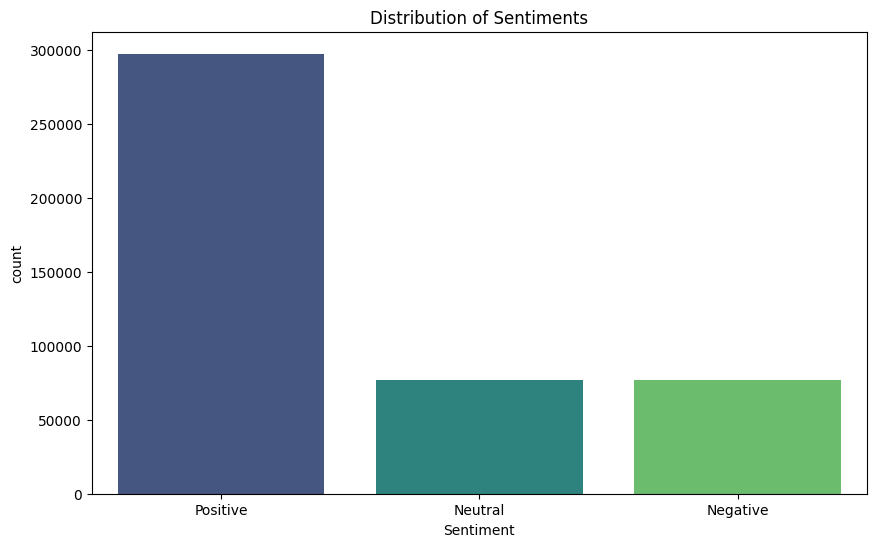

```python
plt.figure(figsize=(10, 6))
sns.countplot(x='Sentiment', data=df, palette='viridis')
plt.title('Distribution of Sentiments')
plt.show()
```

- A count plot is created to visualize the distribution of sentiments in the dataset.
- This helps in understanding the class distribution and identifying any class imbalance.

```python
df['cleaned_Tweet'] = df['Tweet'].apply(clean_text)
df.head()
```

|  | Tweet | Sentiment | cleaned_Tweet |
| --- | --- | --- | --- |
| 0 | @_angelica_toy Happy Anniversary!!!....The Day... | Positive | happy anniversary the day the freedumb died in... |
| 1 | @McfarlaneGlenda Happy Anniversary!!!....The D... | Positive | happy anniversary the day the freedumb died in... |
| 2 | @thevivafrei @JustinTrudeau Happy Anniversary!... | Positive | happy anniversary the day the freedumb died in... |
| 3 | @NChartierET Happy Anniversary!!!....The Day t... | Positive | happy anniversary the day the freedumb died in... |
| 4 | @tabithapeters05 Happy Anniversary!!!....The D... | Positive | happy anniversary the day the freedumb died in... |

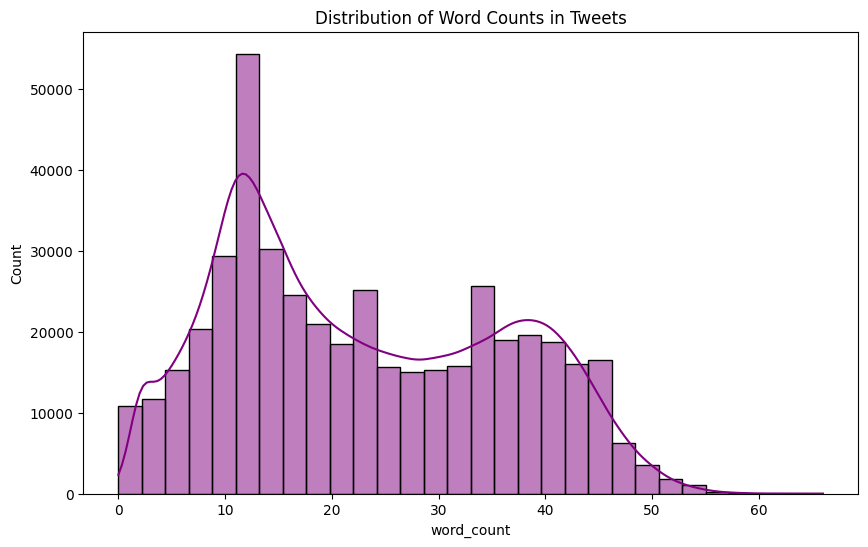

```python
df['word_count'] = df['cleaned_Tweet'].apply(lambda x: len(str(x).split()))
plt.figure(figsize=(10, 6))
sns.histplot(df['word_count'], kde=True, bins=30, color='purple')
plt.title('Distribution of Word Counts in Tweets')
plt.show()
```

- A histogram of word counts is plotted to visualize the distribution of tweet lengths.
- This helps in understanding the typical length of tweets and aids in setting an appropriate maximum sequence length for the model.

### Balanced Dataset

```python
df = df.groupby('Sentiment').apply(lambda x: x.sample(n=76612, replace=True)).reset_index(drop=True)
```

```python
texts = df['cleaned_Tweet'].astype(str).values
labels = df['Sentiment'].values
```

#### Maping

```python
label_mapping = {'Negative': 0, 'Neutral': 1, 'Positive': 2}
labels = np.array([label_mapping[label] for label in labels])
```

```python
X_train, X_test, y_train, y_test = train_test_split(texts, labels, test_size=0.2, random_state=42)
```

- The dataset is balanced by sampling the same number of instances for each sentiment category.
- Texts and labels are extracted and converted to integer labels.
- The data is split into training and testing sets to evaluate model performance.

### Preprocess Text Model

```python
lemmatizer = WordNetLemmatizer()
stop_words = set(stopwords.words('english'))
tokenizer = Tokenizer(num_words=5000)
```

```python
def preprocess_text(tweet):
    tokens = word_tokenize(tweet)
    tokens = [word for word in tokens if word.lower() not in stop_words]
    tokens = [lemmatizer.lemmatize(word) for word in tokens]
    tweet = ' '.join(tokens)
    return tweet
```

```python
X_train = [preprocess_text(tweet) for tweet in X_train]
X_test = [preprocess_text(tweet) for tweet in X_test]
```

### Tokenizer

```python
tokenizer.fit_on_texts(X_train)
X_train_seq = tokenizer.texts_to_sequences(X_train)
X_test_seq = tokenizer.texts_to_sequences(X_test)
```

### Uniform input size

```python
X_train_pad = pad_sequences(X_train_seq, maxlen=30)
X_test_pad = pad_sequences(X_test_seq, maxlen=30)
```

- A tokenizer is used to convert text to sequences of integers.
- The `preprocess_text` function tokenizes, removes stop words, and lemmatizes the text.
- Sequences are padded to a uniform length to ensure consistent input size for the model.

## PCA

```python
from sklearn.decomposition import PCA
```

```python
pca = PCA(n_components=2)
X_train_pca = pca.fit_transform(X_train_pad)
```

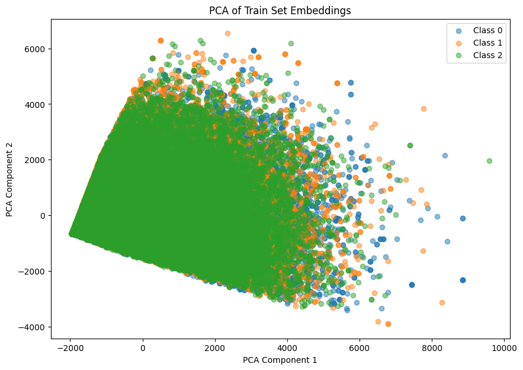

```python
plt.figure(figsize=(10, 7))
for i in np.unique(y_train):
    idxs = np.where(y_train == i)
    plt.scatter(X_train_pca[idxs, 0], X_train_pca[idxs, 1], label=f'Class {i}', alpha=0.5)
plt.xlabel('PCA Component 1')
plt.ylabel('PCA Component 2')
plt.title('PCA of Train Set Embeddings')
plt.legend()
plt.show()
```

- PCA is used to reduce the dimensionality of the training set embeddings to 2D.
- A scatter plot is created to visualize the separability of different classes in the training set.
- This helps in understanding the effectiveness of the preprocessing and the initial distribution of the data.

# positional encoding

```python
class RelativePositionalEncoding(tf.keras.layers.Layer):
    def __init__(self, d_model, max_len=30):
        super(RelativePositionalEncoding, self).__init__()
        self.d_model = d_model
        self.max_len = max_len
        self.pos_encoding = self.relative_positional_encoding(self.max_len, self.d_model)

    def relative_positional_encoding(self, max_len, d_model):
        pos = np.arange(max_len)[:, np.newaxis]
        i = np.arange(d_model)[np.newaxis, :]
        angle_rads = pos / np.power(10000, (2 * (i//2)) / np.float32(d_model))
        angle_rads[:, 0::2] = np.sin(angle_rads[:, 0::2])
        angle_rads[:, 1::2] = np.cos(angle_rads[:, 1::2])
        return tf.cast(angle_rads, dtype=tf.float32)

    def call(self, x):
        seq_len = tf.shape(x)[1]
        x += self.pos_encoding[:seq_len, :]
        return x
```

## Transformers

```python
def transformer_model(vocab_size, d_model, num_heads, ff_dim, num_layers, max_seq_length, l2_reg=0.01, dropout_rate=0.1):
    initializer = tf.keras.initializers.GlorotUniform()

    inputs = tf.keras.Input(shape=(max_seq_length,))
    embedding_layer = tf.keras.layers.Embedding(vocab_size, d_model)(inputs)
    pos_encoding_layer = RelativePositionalEncoding(d_model, max_seq_length)(embedding_layer)

    for _ in range(num_layers):
        attn_output = tf.keras.layers.MultiHeadAttention(num_heads=num_heads, key_dim=d_model)(pos_encoding_layer, pos_encoding_layer)
        attn_output = tf.keras.layers.Dropout(dropout_rate)(attn_output)
        out1 = tf.keras.layers.LayerNormalization(epsilon=1e-6)(pos_encoding_layer + attn_output)

        ffn_output = tf.keras.layers.Dense(ff_dim, activation='relu', kernel_initializer=initializer,
                                           kernel_regularizer=tf.keras.regularizers.l2(l2_reg))(out1)
        ffn_output = tf.keras.layers.Dense(d_model, kernel_initializer=initializer,
                                           kernel_regularizer=tf.keras.regularizers.l2(l2_reg))(ffn_output)
        ffn_output = tf.keras.layers.Dropout(dropout_rate)(ffn_output)
        pos_encoding_layer = tf.keras.layers.LayerNormalization(epsilon=1e-6)(out1 + ffn_output)

    outputs = tf.keras.layers.GlobalAveragePooling1D()(pos_encoding_layer)
    outputs = tf.keras.layers.Dropout(dropout_rate)(outputs)
    outputs = tf.keras.layers.Dense(20, activation='relu', kernel_initializer=initializer,
                                    kernel_regularizer=tf.keras.regularizers.l2(l2_reg))(outputs)
    outputs = tf.keras.layers.Dense(3, activation='softmax', kernel_initializer=initializer,
                                    kernel_regularizer=tf.keras.regularizers.l2(l2_reg))(outputs)

    return tf.keras.Model(inputs=inputs, outputs=outputs)
```

- A transformer model is defined with embedding layers, multi-head attention, and feed-forward neural network layers.
- Relative positional encoding is added to the embeddings.
- The model includes dropout and layer normalization for regularization.
- The final layers consist of global average pooling, dense layers, and a softmax activation for classification.

### Evaluatation model

```python
vocab_size = 5000
d_model = 64
num_heads = 8
ff_dim = 32
num_layers = 1
max_seq_length = 30

model = transformer_model(vocab_size, d_model, num_heads, ff_dim, num_layers, max_seq_length, dropout_rate=0.1)
model.compile(optimizer='adam', loss='sparse_categorical_crossentropy', metrics=['accuracy'])
model.summary()
```

```
Model: "model"
__________________________________________________________________________________________________
 Layer (type)                Output Shape                 Param #   Connected to
==================================================================================================
 input_1 (InputLayer)        [(None, 30)]                 0         []

 embedding (Embedding)       (None, 30, 64)               320000    ['input_1[0][0]']

 relative_positional_encodi  (None, 30, 64)               0         ['embedding[0][0]']
 ng (RelativePositionalEnco
 ding)

 multi_head_attention (Mult  (None, 30, 64)               132672    ['relative_positional_encoding
 iHeadAttention)                                                    [0][0]',
                                                                     'relative_positional_encoding
                                                                    [0][0]']

 dropout (Dropout)           (None, 30, 64)               0         ['multi_head_attention[0][0]']

 tf.__operators__.add (TFOp  (None, 30, 64)               0         ['relative_positional_encoding
 Lambda)                                                            [0][0]',
                                                                     'dropout[0][0]']

 layer_normalization (Layer  (None, 30, 64)               128       ['tf.__operators__.add[0][0]']
 Normalization)

 dense (Dense)               (None, 30, 32)               2080      ['layer_normalization[0][0]']

 dense_1 (Dense)             (None, 30, 64)               2112      ['dense[0][0]']

 dropout_1 (Dropout)         (None, 30, 64)               0         ['dense_1[0][0]']

 tf.__operators__.add_1 (TF  (None, 30, 64)               0         ['layer_normalization[0][0]',
 OpLambda)                                                           'dropout_1[0][0]']

 layer_normalization_1 (Lay  (None, 30, 64)               128       ['tf.__operators__.add_1[0][0]
 erNormalization)                                                   ']

 global_average_pooling1d (  (None, 64)                   0         ['layer_normalization_1[0][0]'
 GlobalAveragePooling1D)                                            ]

 dropout_2 (Dropout)         (None, 64)                   0         ['global_average_pooling1d[0][
                                                                    0]']

 dense_2 (Dense)             (None, 20)                   1300      ['dropout_2[0][0]']

 dense_3 (Dense)             (None, 3)                    63        ['dense_2[0][0]']

==================================================================================================
Total params: 458483 (1.75 MB)
Trainable params: 458483 (1.75 MB)
Non-trainable params: 0 (0.00 Byte)
__________________________________________________________________________________________________
```

### class weights

```python
from sklearn.utils import compute_class_weight
```

```python
class_weights = compute_class_weight('balanced', classes=np.unique(y_train), y=y_train)
class_weights = {i: class_weights[i] for i in range(len(class_weights))}
```

### Early stopping & learning rate reduction

```python
early_stopping = tf.keras.callbacks.EarlyStopping(monitor='val_loss', patience=3, restore_best_weights=True)
reduce_lr = tf.keras.callbacks.ReduceLROnPlateau(monitor='val_loss', factor=0.1, patience=3, min_lr=1e-6, verbose=1)
```

### Train the model

```python
start_time = time.time()
history = model.fit(X_train_pad, y_train, epochs=20, batch_size=32, validation_split=0.1,
                    callbacks=[early_stopping, reduce_lr], class_weight=class_weights)
elapsed_time = time.time() - start_time
print(f"Time taken for training: {elapsed_time:.2f} seconds")
```

```
Epoch 12: ReduceLROnPlateau reducing learning rate to 0.00010000000474974513.
Time taken for training: 639.66 seconds
```

- The model is compiled with Adam optimizer and sparse categorical cross-entropy loss.
- Class weights are computed to handle class imbalance.
- Early stopping and learning rate reduction are used to prevent overfitting and adjust the learning rate during training.
- The model is trained with class weights, early stopping, and learning rate reduction callbacks.

### Evalute Model

```
Classification Report:
              precision    recall  f1-score   support

    Negative       0.79      0.79      0.79     15192
     Neutral       0.78      0.70      0.74     15187
    Positive       0.76      0.83      0.79     15589

    accuracy                           0.78     45968
   macro avg       0.78      0.78      0.78     45968
weighted avg       0.78      0.78      0.78     45968
```

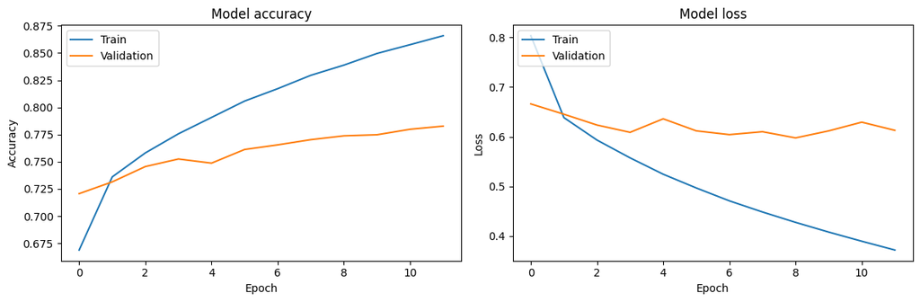

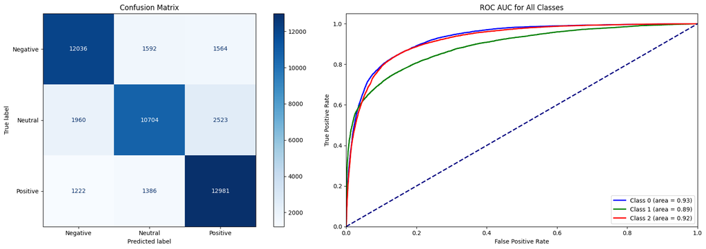

```python
def evaluate_model_performance(model, X_test_pad, y_test, history):
    y_test_pred = np.argmax(model.predict(X_test_pad), axis=-1)
    print("Classification Report:")
    print(classification_report(y_test, y_test_pred, target_names=['Negative', 'Neutral', 'Positive']))

    plt.figure(figsize=(12, 4))
    plt.subplot(1, 2, 1)
    plt.plot(history.history['accuracy'])
    plt.plot(history.history['val_accuracy'])
    plt.title('Model accuracy')
    plt.ylabel('Accuracy')
    plt.xlabel('Epoch')
    plt.legend(['Train', 'Validation'], loc='upper left')

    plt.subplot(1, 2, 2)
    plt.plot(history.history['loss'])
    plt.plot(history.history['val_loss'])
    plt.title('Model loss')
    plt.ylabel('Loss')
    plt.xlabel('Epoch')
    plt.legend(['Train', 'Validation'], loc='upper left')

    plt.tight_layout()
    plt.show()

    y_pred = model.predict(X_test_pad)
    y_pred_classes = np.argmax(y_pred, axis=1)
    cm = confusion_matrix(y_test, y_pred_classes)

    y_test_binarized = label_binarize(y_test, classes=[0, 1, 2])
    y_pred_binarized = label_binarize(y_pred_classes, classes=[0, 1, 2])

    fpr = dict()
    tpr = dict()
    roc_auc = dict()
    for i in range(3):
        fpr[i], tpr[i], _ = roc_curve(y_test_binarized[:, i], y_pred[:, i])
        roc_auc[i] = auc(fpr[i], tpr[i])

    fig, axes = plt.subplots(1, 2, figsize=(18, 6))
    disp = ConfusionMatrixDisplay(confusion_matrix=cm, display_labels=['Negative', 'Neutral', 'Positive'])
    disp.plot(cmap=plt.cm.Blues, ax=axes[0])
    axes[0].set_title('Confusion Matrix')

    ax = axes[1]
    colors = ['blue', 'green', 'red']
    for i, color in zip(range(3), colors):
        ax.plot(fpr[i], tpr[i], color=color, lw=2, label='Class {0} (area = {1:0.2f})'.format(i, roc_auc[i]))
    ax.plot([0, 1], [0, 1], color='navy', lw=2, linestyle='--')
    ax.set_xlim([0.0, 1.0])
    ax.set_ylim([0.0, 1.05])
    ax.set_title('ROC AUC for All Classes')
    ax.set_xlabel('False Positive Rate')
    ax.set_ylabel('True Positive Rate')
    ax.legend(loc="lower right")

    plt.tight_layout()
    plt.show()

evaluate_model_performance(model, X_test_pad, y_test, history)
```

- The `evaluate_model_performance` function evaluates the trained model's performance on the test set.
- It prints a classification report, plots accuracy and loss curves, and displays a confusion matrix and ROC AUC curves.

```python
import lime
import lime.lime_text
from sklearn.pipeline import make_pipeline
```

```python
!pip install lime
```

```python
def predict_fn(texts):
    sequences = tokenizer.texts_to_sequences(texts)
    padded_sequences = pad_sequences(sequences, maxlen=30)
    return model.predict(padded_sequences)
```

```python
explainer = lime.lime_text.LimeTextExplainer(class_names=['Negative', 'Neutral', 'Positive'])
```

```python
i = 5000
explanation = explainer.explain_instance(X_test[i], predict_fn, num_features=10)
```

```python
explanation.show_in_notebook(text=True)
```

[output not shown]

```python
df
```

|  | Tweet | Sentiment | cleaned_Tweet | word_count |
| --- | --- | --- | --- | --- |
| 0 | And Weâll rise up\nrise like the day\nWeâl... | Negative | and we ll rise up rise like the day we ll rise... | 57 |
| 1 | @CBCNews not unlike freedom convoy changed thi... | Negative | not not_unlike freedom convoy changed things i... | 31 |
| 2 | @CulDeSacHero @gmbutts Bingo. Dumbass parents ... | Negative | bingo dumbass parents were scaring their kids ... | 21 |
| 3 | Canada Freedom Convoy: Nearly 200 arrested as ... | Negative | canada freedom convoy nearly arrested as ottaw... | 13 |
| 4 | GOT him! Now prosecute him to the fullest exte... | Negative | got him now prosecute him to the fullest exten... | 15 |
| ... | ... | ... | ... | ... |
| 229831 | This is what true devotion to democracy and fr... | Positive | this is what true devotion to democracy and fr... | 17 |
| 229832 | Negotiator behind deal with Freedom Convoy htt... | Positive | negotiator behind deal with freedom convoy dea... | 40 |
| 229833 | @melsmartin26 @TheRealKeean Read some philosop... | Positive | read some philosophy about freedom before you ... | 18 |
| 229834 | @TheFrenchWong Sections of the middle classes ... | Positive | sections of the middle classes can come over t... | 42 |
| 229835 | @trumpanizer @MinuteLibre la pape mobile a Ã©v... | Positive | la pape mobile a vit tout les nids poule ils o... | 23 |

229836 rows × 4 columns